# Calculating $p$-values in R: A Quick and Dirty Guide

Jeffrey M. Pisklak

2025-06-27

- Critical Region ($\alpha = .05$) is shown in light red.
- Solid vertical black line is the test-statistic.
- The probability of a test-statistic (i.e. $p$-value) is shown in brown.
- Degrees of freedom are set to 4 in all examples.
- Additional notes pertaining to one- and two-sided confidence interval calculations are also provided.

# **Two-Tailed Tests**

##### For two-tailed tests, what is matters is whether the test-statistic lands in the left or right tail; i.e., whether it is negative or positive. Note that the probability (i.e., $p$-value’s area under the curve) is mirrored in the case of two-tailed tests.

### 1. If your **test-statistic is negative** (e.g., $T = -1.5$), then you are going to use . . .

```r
pt(-1.5, df = 4) * 2
```

```
## [1] 0.208
```

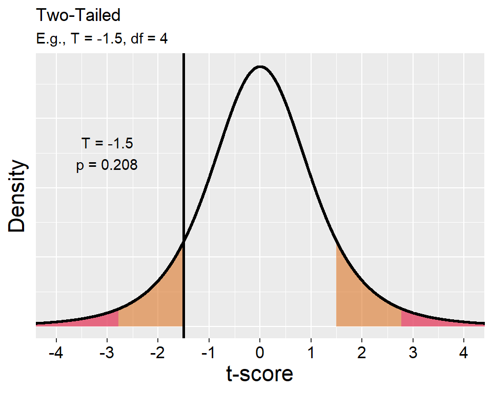

**Confidence Interval Information**

$\begin{aligned} \text{Confidence Interval} &= \bar{x} \pm \text{(critical $t$-score)} \cdot \text{(standard error)} \\ &= [\text{ lower bound}, \text{ upper bound }] \end{aligned}$

```r
# Critical t-calculation
alpha <- 0.05
abs(qt(alpha / 2, df = 4))
```

```
## [1] 2.776445
```

- The absolute value (`abs()`) is used because the confidence interval equation already accounts for the direction of each boundary through addition (+) and subtraction (-). This eliminates the need to compute separate critical $t$-scores for each side.

### 2. If your **test-statistic is positive** (e.g., $T = 1.5$), then you are going to use . . .

```r
pt(1.5, df = 4, lower.tail = FALSE) * 2
```

```
## [1] 0.208
```

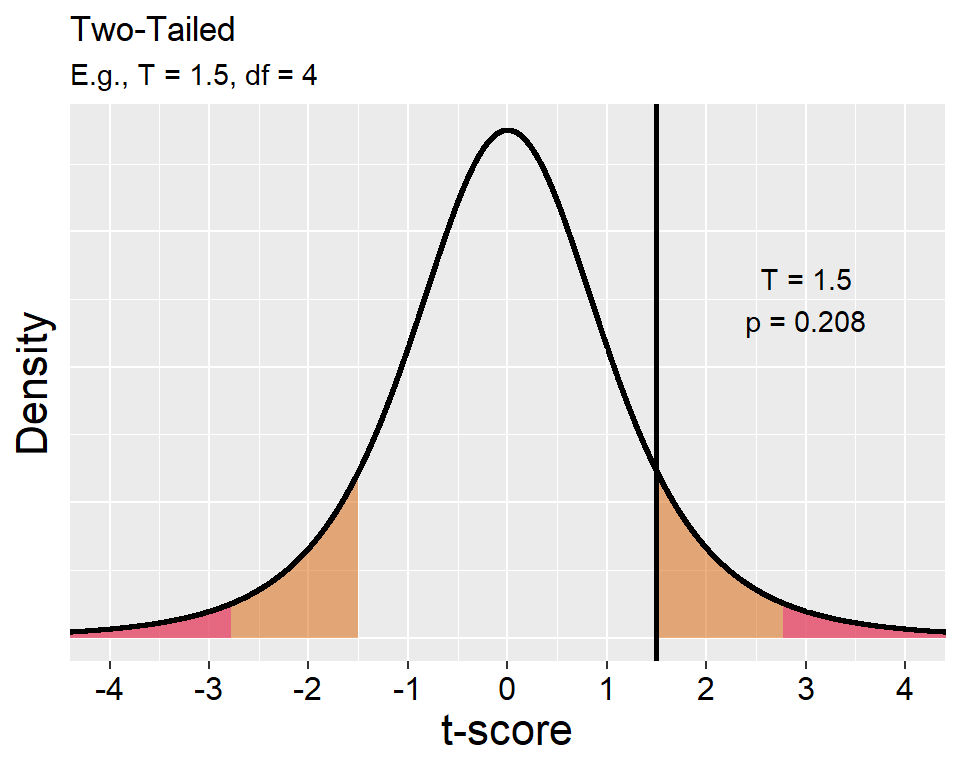

**Confidence Interval Information**

$\begin{aligned} \text{Confidence Interval} &= \bar{x} \pm \text{(critical $t$-score)} \cdot \text{(standard error)} \\ &= [\text{ lower bound}, \text{ upper bound }] \end{aligned}$

```r
# Critical t-calculation
alpha <- 0.05
abs(qt(alpha / 2, df = 4))
```

```
## [1] 2.776445
```

- The absolute value (`abs()`) is used because the confidence interval equation already accounts for the direction of each boundary through addition (+) and subtraction (-). This eliminates the need to compute separate critical $t$-scores for each side.

# **One-tailed tests**

##### For one-tailed tests, what is matters is where the critical region (red) is located (left or right tail). This is determined by the null hypothesis. Whether the test-statistic is positive or negative has no bearing on how the $p$-value is calculated.

### 3. If your **critical region is in the left tail** (e.g., $H_0 : \mu \geq 1.5$) then you are going to use . . .

```r
pt(1.5, df = 4)
```

```
## [1] 0.896
```

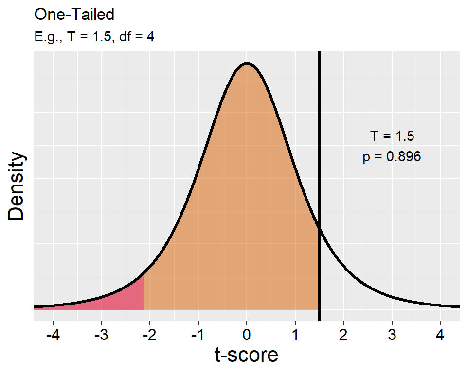

**Confidence Interval Information**

$\begin{aligned} \text{Confidence Interval} &= \bar{x} + \text{(critical $t$-score)} \cdot \text{(standard error)} \\ &= (-\infty, \text{ upper bound }] \end{aligned}$

```r
# Critical t-calculation
alpha <- 0.05
abs(qt(alpha, df = 4))
```

```
## [1] 2.131847
```

- The confidence interval is expressed in terms of the alternative hypothesis $H_1: \mu < 1.5$.
- For one-tailed tests, the critical $t$-score is calculated using the *entire* significance level $\alpha$.
- The absolute value (`abs()`) is used because the direction of the boundary is already specified by the addition (+) in the confidence interval equation.

### 4. If your **critical region is in the right tail** (e.g., $H_0 : \mu \leq 1.5$) then you are going to use . . .

```r
pt(1.5, df = 4, lower.tail = FALSE)
```

```
## [1] 0.104
```

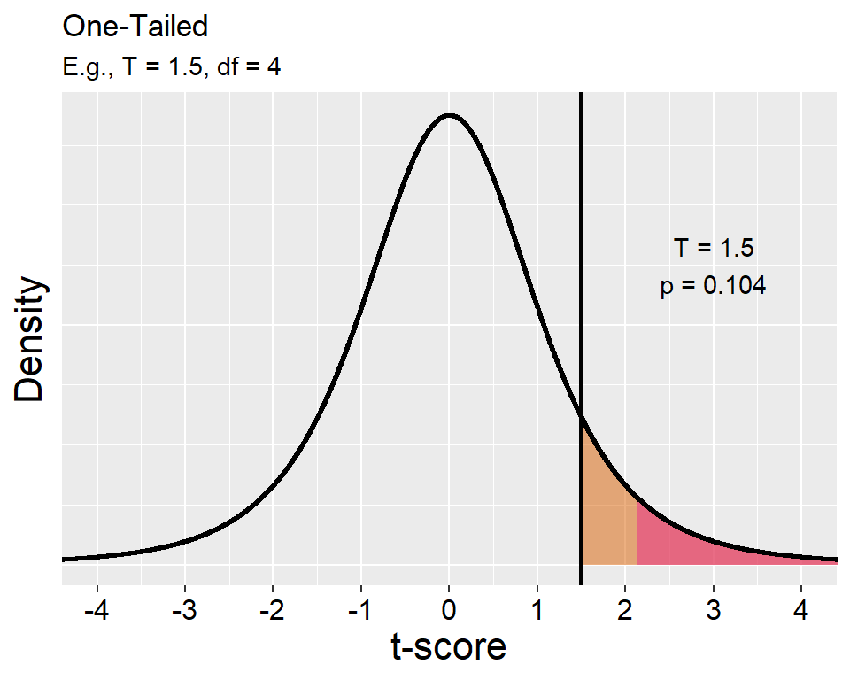

**Confidence Interval Information**

$\begin{aligned} \text{Confidence Interval} &= \bar{x} - \text{(critical $t$-score)} \cdot \text{(standard error)} \\ &= [\text{ lower bound}, \infty) \end{aligned}$

```r
# Critical t-calculation
alpha <- 0.05
abs(qt(alpha, df = 4))
```

```
## [1] 2.131847
```

- The confidence interval is expressed in terms of the alternative hypothesis $H_1: \mu > 1.5$.
- For one-tailed tests, the critical $t$-score is calculated using the *entire* significance level $\alpha$.
- The absolute value (`abs()`) is used because the direction of the boundary is already specified by the subtraction (-) in the confidence interval equation.